# Investments

Week 2 – Tutorial 2  
Utz Weitzel & Eva Mynott – VU Finance

# Prepare session

In RStudio, open a project, or make a new one.

.

**Clear the console**

Ctrl + L (Windows) or Option + Command + L (iOS)

.

**Clear the environment**

```r
rm(list = ls(all.names = TRUE))
```

.

**Tidyverse package**

If you haven’t done so already, install the tidyverse package

```
install.packages("tidyverse") # once per machine
```

Load the tidyverse package

```r
library(tidyverse) # at the start of every session
options(dplyr.summarise.inform = FALSE)
```

**Note**

The options() command above suppresses some messages when grouping and summarizing, which are helpful for debugging but can also be distracting or clutter output. Setting this option to FALSE leads to a cleaner console output.

.

.

.

# Event Studies: N Events, N Stocks

.

For this section, we import data set `df203` with *daily* abnormal returns estimated with the FF3 model.

.

The estimation window was 100 trading days (at least 70 days with trading data), with a gap of 50 trading days before the event date `evtdate`. The event date is the day where a US firm (listed on the NYSE or NASDAQ) announced a data breach in the period from April 2005 to March 2015.

.

Per stock (listed in `ticker`), the data set contains total returns `re` and FF3 abnormal returns `ra` per event day `evtday` from 10 trading days before to 10 trading days after the event date `evtdate`.

.

**Import the data set**

```r
df203 = read_csv("df203.csv", show_col_types=FALSE)

View(df203)
```

**Note**

A dummy `confound_dum` indicates whether the breach was made public before the official announcement date (e.g., in the press, looked up with searches on LexisNexis) and/or whether the company made any other announcements in the 10 days prior to the incident. The type of confound is recorded in `confound_type`.  
Moreover, `breach_size` and `breach_type` record the announced potential damage of the breach and its type, and `event_state` records in which US state (each with own laws for data breaches) the breach took place. Data source is [Rosati, Pierangelo; Lynn, Theo (2020), “A dataset for accounting, finance and economics research on US data breaches”, Mendeley Data](https://data.mendeley.com/datasets/w33nhh3282/1)

.

There are still some duplicates in the data, let us remove them.

```r
# Remove duplicates
df203 = df203 %>% distinct(evtdate, evtday, ticker, .keep_all = TRUE)
```

.

**Tip**

If you inspect the data carefully, you find that some companies had several data breaches. In an improved regression you might want to include firm fixed effects, but only for firms that are included more than once in the data set.

.

.

## Defining the events

.

**Identify the number of stocks and event dates**

```r
# Identify unique stocks (tickers)
num_unique_tickers <- df203 %>%
  distinct(ticker) %>%
  nrow()

# Identify unique event dates
num_unique_eventdates <- df203 %>%
  distinct(evtdate) %>%
  nrow()

# Print the results
cat("Number of unique tickers:", num_unique_tickers, "\n")
```

```
Number of unique tickers: 211
```

```r
cat("Number of unique event dates:", num_unique_eventdates, "\n")
```

```
Number of unique event dates: 349
```

We observe that we have 211 different stocks and 349 different event dates. But how many actual events do we have?

.

**Give each event a distinct number**

```r
# Create an event number for each event
df203 = df203 |>
  group_by(evtdate, ticker) |> # identify each event
  mutate(evtnum = cur_group_id()) # attribute a number to each event
```

.

**Identify the actual unique events**

```r
# Identify unique events
num_unique_events <- df203 %>%
  distinct(evtnum) %>%
  nrow()

# Print the results
cat("Number of unique events:", num_unique_events, "\n")
```

```
Number of unique events: 383
```

Hence, we have 383 different events.

.

.

## Year fixed effects

.

The events stretch over 10 years and every period is different. Remember the global financial crisis? Let’s make year fixed effects in order to capture some of these period-specific effects.

.

In linear regressions, R automatically creates dummies for each `event_year` (except one to avoid the dummy trap), but only if the variable is added into the regression as a categorical variable.

.

**Create a year dummy**

```r
df203 = df203 |>
  mutate(event_year = as.factor(event_year))
```

event_year is now interpreted as “Factor w/ 11 levels” i.e. a dummy variable with 11 categories.

.

.

## ARs across stocks and events

.

Let’s first take a look at the abnormal returns (ARs) across *all* data breaches (recap).

```r
# Let us define a new variable ar_breach
ar_breach = df203 |>

  # we group by day.. (not to be confused with the date of the event)
  group_by(evtday) |>

  #.. to get the mean of the ARs per day
  summarize(mean_ra = mean(ra, na.rm = TRUE))       # mean AR on a certain day
```

```r
View(ar_breach)
```

.

**Plot of the average Abnormal Returns (ARs) per event day**

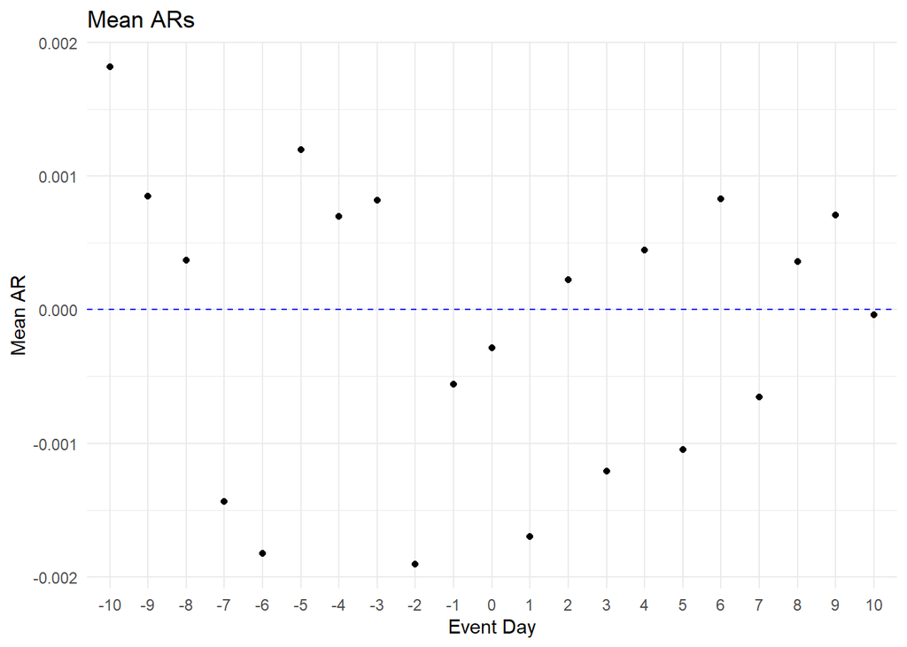

```r
# Use ggplot to plot the avg AR (y-axis) and the event days (x-axis)
ggplot(ar_breach, aes(x = as.factor(evtday), y = mean_ra)) +
  geom_point() +
  # Add a title and labels for the axes
  labs(x = "Event Day", y = "Mean AR", title = "Mean ARs") +
  geom_hline(yintercept = 0, color = "blue", linetype = "dashed") +  # Add line   at zero
  theme_minimal()
```

.

**Plot of the Abnormal Returns (ARs) per event day**

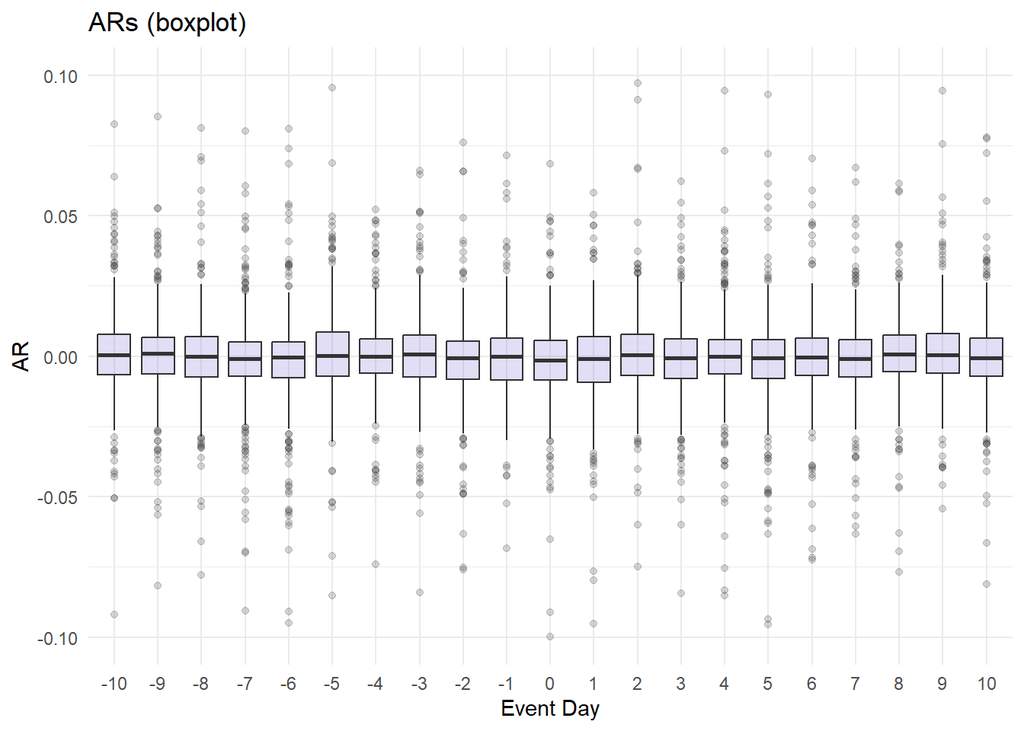

```r
# Use ggplot to plot the AR (y-axis) and the event days (x-axis)
ggplot(df203, aes(x = as.factor(evtday), y = ra)) +
  geom_boxplot(fill="slateblue", alpha=0.2) +
  # Add a title and labels for the axes
  labs(x = "Event Day", y = "AR", title = "ARs (boxplot)") +
  ylim(c(-0.1, 0.1)) +  # Set y-axis limits
  theme_minimal()
```

The mean ARs look quite dispersed in the first plot, but when looking at the box plot, we can see that the mean AR is very small in magnitude. This gives us a first indication that the effect may be insignificant.

.

.

## CARs for different events

.

If the announcement was a surprise to the market, tight event windows capture the effect best. However, if there was information leakage beforehand, a wider window before the event date `evtdate` is helpful (but comes at the cost of including more noise).

.

```r
# The CAR for days -10 to +1
dfcarb12 = df203 |>
  filter(evtday>=-10 & evtday<=1) |> # the event days to include
  group_by(evtnum) |> # do this for each distinct event
  mutate(car12 = sum(ra, na.rm=T)) |> # sum the abnormal returns
  filter(evtday==0) # show only the actual event date

# The CAR for days -3 to +1
dfcarb05 = df203 |>
  filter(evtday>=-3 & evtday<=1) |> # the event days to include
  group_by(evtnum) |> # do this for each distinct event
  mutate(car05 = sum(ra, na.rm=T)) |> # sum the abnormal returns
  filter(evtday==0) # show only the actual event date

# The CAR for days -1 to +1
dfcarb03 = df203 |>
  filter(evtday>=-1 & evtday<=1) |> # the event days to include
  group_by(evtnum) |> # do this for each ticker/stock
  mutate(car03 = sum(ra, na.rm=T)) |> # sum the abnormal returns
  filter(evtday==0) # show only the actual event date
```

```r
view(dfcarb05)
```

**Note**

Note that we are mostly interested in the run-up to the event (and not so much the days thereafter), because the news, once announced, is compounded into the price in a matter of minutes/hours.

.

**Histogram of CARs**

Let us plot a histogram of the CARs (across the 383 events)

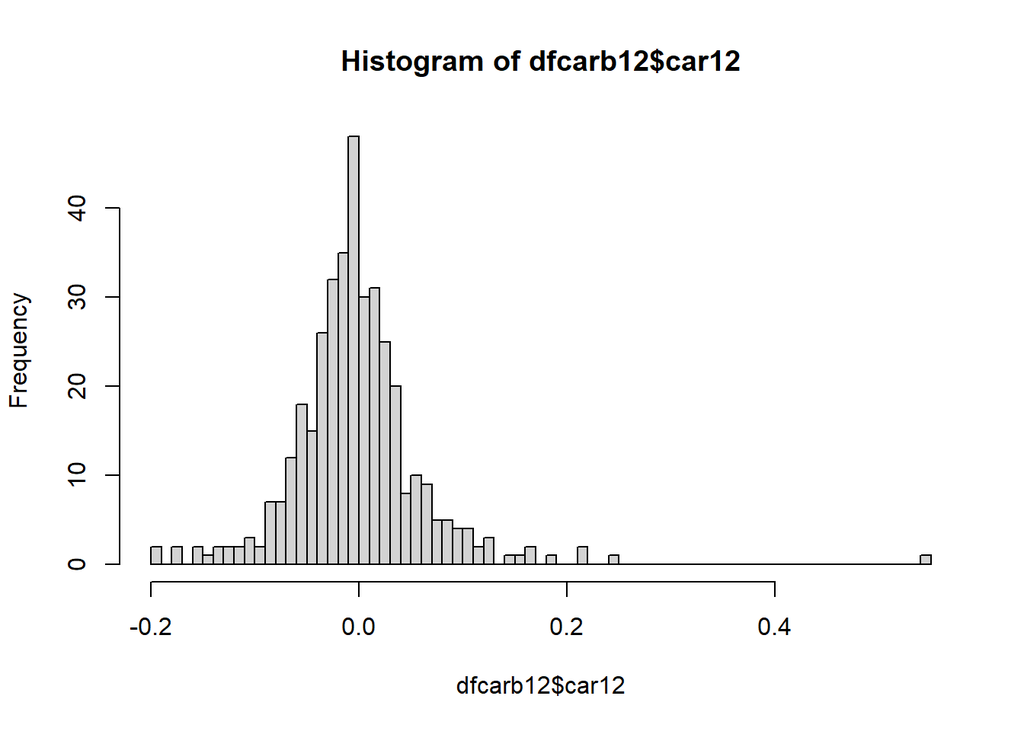

```r
# Create three histograms
hist(dfcarb12$car12, breaks = 100)
```

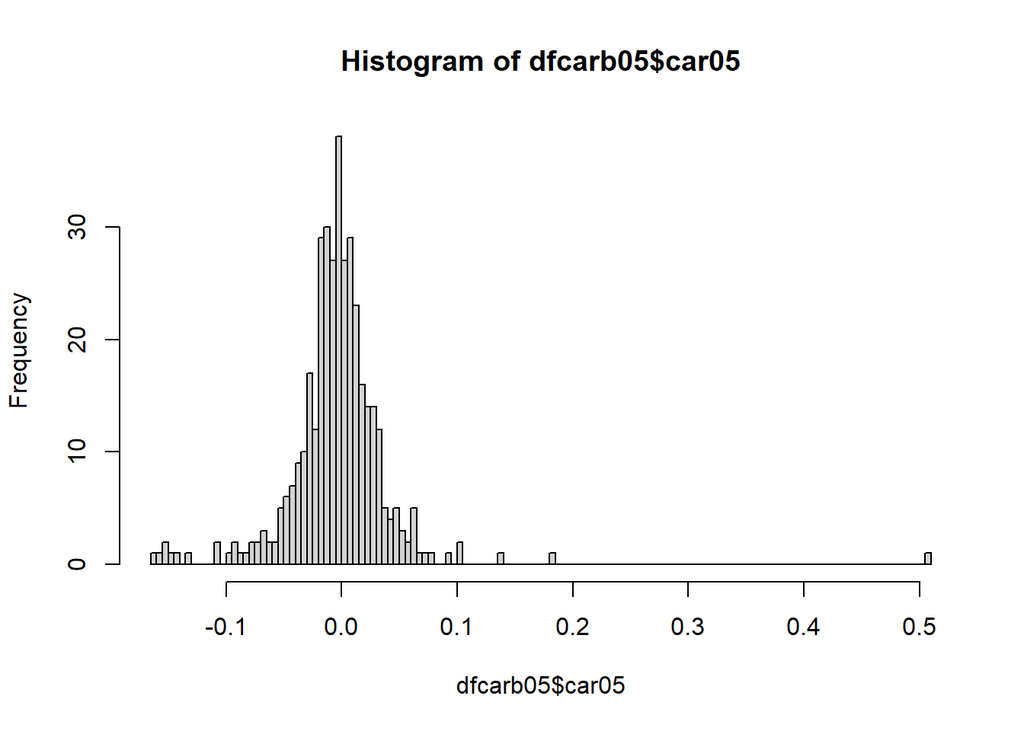

```r
hist(dfcarb05$car05, breaks = 100)
```

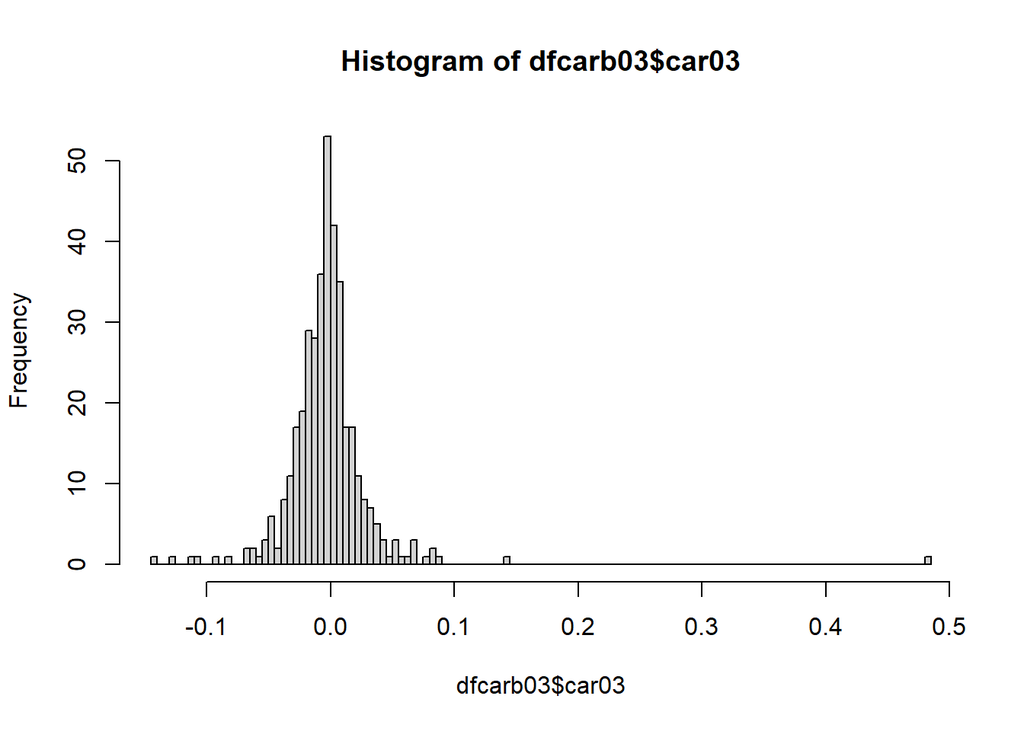

```r
hist(dfcarb03$car03, breaks = 100)
```

.

.

## OLS 1: Confounding events

.

We expect that tighter event windows capture the effect slightly better. However, this could also be due to other announcements that have been made together with the breach (for example earnings announcements) or shortly before.

.

Let us focus on the 5-day event window.

.

**Estimate the linear regression model (OLS 1.1)**

```r
# Fit a linear regression model of the confounding events on the CARs
lm_carb05 = lm(car05 ~ confound_dum, data = dfcarb05)

# Inspect the regression output
summary(lm_carb05)
```

```
Call:
lm(formula = car05 ~ confound_dum, data = dfcarb05)

Residuals:
     Min       1Q   Median       3Q      Max
-0.16325 -0.01543 -0.00015  0.01803  0.50991

Coefficients:
              Estimate Std. Error t value Pr(>|t|)
(Intercept)  -0.005532   0.002974  -1.860   0.0637 .
confound_dum  0.005209   0.004919   1.059   0.2904
---
Signif. codes:  0 '***' 0.001 '**' 0.01 '*' 0.05 '.' 0.1 ' ' 1

Residual standard error: 0.04636 on 381 degrees of freedom
Multiple R-squared:  0.002934,  Adjusted R-squared:  0.0003169
F-statistic: 1.121 on 1 and 381 DF,  p-value: 0.2904
```

.

Confounding events do not seem to matter much here (`confound_dum` is not significant at the 5% or 10% level). Furthermore, the intercept is negative and statistically significant at the 10% level, indicating that the average sample CAR is negative. But what about the year fixed effects?

.

**Estimate the linear regression model (OLS 1.2)**

```r
# Fit a linear regression model of the year and confounding events on the CARs
lm_carb05 = lm(car05 ~ confound_dum + factor(event_year), data = dfcarb05)

# Inspect the regression output
summary(lm_carb05)
```

```
Call:
lm(formula = car05 ~ confound_dum + factor(event_year), data = dfcarb05)

Residuals:
     Min       1Q   Median       3Q      Max
-0.16264 -0.01604  0.00009  0.01739  0.50298

Coefficients:
                        Estimate Std. Error t value Pr(>|t|)
(Intercept)            -0.004821   0.011541  -0.418    0.676
confound_dum            0.004638   0.005122   0.905    0.366
factor(event_year)2006  0.007030   0.012915   0.544    0.587
factor(event_year)2007 -0.004287   0.013100  -0.327    0.744
factor(event_year)2008  0.002904   0.014215   0.204    0.838
factor(event_year)2009 -0.007879   0.016821  -0.468    0.640
factor(event_year)2010  0.006787   0.012972   0.523    0.601
factor(event_year)2011 -0.010988   0.013319  -0.825    0.410
factor(event_year)2012 -0.007627   0.013639  -0.559    0.576
factor(event_year)2013 -0.001504   0.013253  -0.113    0.910
factor(event_year)2014  0.004548   0.013827   0.329    0.742
factor(event_year)2015 -0.011861   0.034787  -0.341    0.733

Residual standard error: 0.04654 on 371 degrees of freedom
Multiple R-squared:  0.02196,   Adjusted R-squared:  -0.007041
F-statistic: 0.7572 on 11 and 371 DF,  p-value: 0.6829
```

**Note**

DIY: Try the regressions with car03 and car12. Do the results change?

We observe that year fixed effects seem redundant for this data sample (F statistic 0.7572 with p-value 0.6829).

.

.

## OLS 2: Breach size (DIY)

.

Now we hypothesize that maybe small breaches are not affecting stock prices a lot, but larger ones do. In order to reduce the effect of outliers in the breach size, we take the log of the `breach_size` before we include it into the regression model.

.

**Create a new variable log_brsize which is the log of breach_size**

```r
dfcarb05 = dfcarb05 |>
  mutate(log_brsize = log(breach_size))
```

.

**Estimate the linear regression model (OLS 2)**

```r
# Fit a linear regression model of the year, confounding events and the log of the breach size on the CARs
lm_carb05 = lm(car05 ~ confound_dum + log_brsize + factor(event_year), data = dfcarb05)

# Inspect the regression output
summary(lm_carb05)
```

```
Call:
lm(formula = car05 ~ confound_dum + log_brsize + factor(event_year),
    data = dfcarb05)

Residuals:
      Min        1Q    Median        3Q       Max
-0.153643 -0.013242  0.001652  0.022150  0.147582

Coefficients:
                         Estimate Std. Error t value Pr(>|t|)
(Intercept)             0.0105167  0.0162847   0.646    0.519
confound_dum           -0.0055263  0.0059646  -0.927    0.355
log_brsize             -0.0011116  0.0007817  -1.422    0.157
factor(event_year)2006  0.0061861  0.0144564   0.428    0.669
factor(event_year)2007 -0.0030646  0.0145771  -0.210    0.834
factor(event_year)2008  0.0109924  0.0158179   0.695    0.488
factor(event_year)2009 -0.0165077  0.0218850  -0.754    0.452
factor(event_year)2010 -0.0094686  0.0153052  -0.619    0.537
factor(event_year)2011 -0.0127369  0.0157403  -0.809    0.419
factor(event_year)2012 -0.0262370  0.0159701  -1.643    0.102
factor(event_year)2013 -0.0070013  0.0167277  -0.419    0.676
factor(event_year)2014  0.0007011  0.0171348   0.041    0.967
factor(event_year)2015  0.0028238  0.0418681   0.067    0.946

Residual standard error: 0.03982 on 189 degrees of freedom
  (181 observations deleted due to missingness)
Multiple R-squared:  0.07389,   Adjusted R-squared:  0.01509
F-statistic: 1.257 on 12 and 189 DF,  p-value: 0.2477
```

**Caution**

Note the information in the output: “181 observations deleted due to missingness”. Due to the many missing values in the variable `breach_size`, we now have a completely different sample. For a rough comparison, we could rerun the previous regression with the same sample, i.e. the sample that has data available for `breach_size`, and see whether there are any changes due to sample selection.

.

.

## OLS 3: Subset of the data (DIY)

.

**Estimate the linear regression model (OLS 3.1)**

Take the subset of the data that has no missing values for breach size (rerun OLS 1.1)

```r
# Fit a linear regression model of confounding events on the CARs using only the subset of data with non-missing values
lm_carb05 = lm(car05 ~ confound_dum, data = dfcarb05, subset = !is.na(log_brsize))

# Inspect the regression output
summary(lm_carb05)
```

```
Call:
lm(formula = car05 ~ confound_dum, data = dfcarb05, subset = !is.na(log_brsize))

Residuals:
      Min        1Q    Median        3Q       Max
-0.155979 -0.012553  0.003618  0.020574  0.140673

Coefficients:
              Estimate Std. Error t value Pr(>|t|)
(Intercept)  -0.004579   0.003716  -1.232    0.219
confound_dum -0.003014   0.005729  -0.526    0.599

Residual standard error: 0.04019 on 200 degrees of freedom
Multiple R-squared:  0.001383,  Adjusted R-squared:  -0.00361
F-statistic: 0.2769 on 1 and 200 DF,  p-value: 0.5993
```

.

**Estimate the linear regression model (OLS 3.2)**

Take the subset of the data that has no missing values for breach size (rerun OLS 1.2)

```r
# Fit a linear regression model of the year and confounding events on the CARs using only the subset of data with non-missing values
lm_carb05 = lm(car05 ~ confound_dum + factor(event_year), data = dfcarb05, subset = !is.na(log_brsize))

# Inspect the regression output
summary(lm_carb05)
```

```
Call:
lm(formula = car05 ~ confound_dum + factor(event_year), data = dfcarb05,
    subset = !is.na(log_brsize))

Residuals:
      Min        1Q    Median        3Q       Max
-0.154486 -0.013117  0.002255  0.021637  0.144152

Coefficients:
                        Estimate Std. Error t value Pr(>|t|)
(Intercept)            -0.003545   0.012973  -0.273    0.785
confound_dum           -0.004962   0.005967  -0.832    0.407
factor(event_year)2006  0.011054   0.014083   0.785    0.433
factor(event_year)2007  0.001384   0.014276   0.097    0.923
factor(event_year)2008  0.013679   0.015747   0.869    0.386
factor(event_year)2009 -0.014068   0.021876  -0.643    0.521
factor(event_year)2010 -0.004512   0.014943  -0.302    0.763
factor(event_year)2011 -0.007322   0.015314  -0.478    0.633
factor(event_year)2012 -0.022223   0.015761  -1.410    0.160
factor(event_year)2013 -0.005255   0.016727  -0.314    0.754
factor(event_year)2014  0.001898   0.017160   0.111    0.912
factor(event_year)2015  0.002695   0.041981   0.064    0.949

Residual standard error: 0.03993 on 190 degrees of freedom
Multiple R-squared:  0.06398,   Adjusted R-squared:  0.009789
F-statistic: 1.181 on 11 and 190 DF,  p-value: 0.3028
```

**Important**

Overall we can see that the data breaches do not really influence the affected company’s stock performance.